# ENVR 420: Assignment 1

Trevor Baker

23/09/2019

# Assignment:

## Explore the rainfall dataset to address the following questions:

### 1. Describe the differences between measurement techniques for the Main, Vaisala, and Atmos sensors.

- the Main gauge is a tipping bucket. It measures rainfall with the tipping bucket method. It measures rainfall by counting the number of tips of a see-saw that is positioned under the outlet of a funnel. Tips cause electronic signals that are counted. By knowing how many tips occur, how much water it takes to tip it, and the collection area of the funnel, the total precipitation can be calculated.
  - *Pros:*
    - The most common and accepted way to measure precipitation. Data from tipping buckets should be the easiest to compare to other studies without considering differences in measurement technique.
    - The mechanism of measurement is very simple and requires little maintenance, much of which can be done in-house without sending to specialized technicians.
    - Relatively cheap to buy compared to piezometric sensors.
    - Require few datalogger channels.
  - *Cons:*
    - The measurements have low resolution because enough water needs to build up to cause drops to run down the funnel, and then enough needs to collect in the mechanism to cause a tip.
    - Small precipitation events could even be missed if not enough water builds up to cause a tip and it gets evaporated.
    - The funnel and see-saw requires maintenance to clear debris and ensure it is not jammed and tipping freely.
- the Atmos sensor works similarly to the Main tipping bucket sensor. However, rather than counting tips, the number of drops passing out of the bottom of the funnel are counted via an electronic sensor. The mass of the drops is known as it is a property of the funnel tip.
  - *Pros:*
    - Measure smaller rain events and have finer resolution than the tipping bucket because it doesn’t require as much water to trigger its drip counter as is needed to cause a tip.
    - No mechanical tipping mechanism to become jammed or sticky.
  - *Cons:*
    - Requires enough water to build up to run down the funnel and be counted. It may, therefore, miss small precipitation events, such as mist.
    - The drip counting mechanism is unlikely to be fixable in-house if it stops working.
    - There is still a funnel that requires debris to be cleared.
- the Vaisala gauges measure rainfall with a piezometric sensor that, via an algorithm, relates the force (i.e. pressure) of a rainfall impact to raindrop mass. Since the area of the piezometric sensor is known, the cumulative mass of water that has fallen can be converted into a rate per unit area per time.
  - *Pros:*
    - Measure all rain intensities instantaneously giving finer resolution
    - Don’t miss small events because of requiring drops to form and trigger mechanisms.
    - Have integrated windspeed and relative humidity sensors.
    - Do not require as much maintenance because there is no funnel to clog or tipping mechanism to jam.
  - *Cons:*
    - More expensive than the other two sensor types.
    - Harder to fix and probably require shipment to specialized technicians.
    - Problems are not easy to diagnose, as with the V2 sensor in this problem set.

### 2. Describe the differences in the resulting data between the different rain sensors.

- At an initial glance, one difference that stands out is the Main gauge, which is a tipping bucket, shows a step pattern to the cumulative distribution of rainfall in the graph below. This is because enough water needs to collect in order for a tip to occur so it has a coarse resolution to the size of rainfall event it can describe, i.e. it counts in discrete steps that appear to be 0.2 mm each.
- Another difference that the cumulative distribution graph shows below is that the maximum depth of rain measured in one half-hour interval by both the Main and Atmos gauges was in the range of 1.5 to 2.0 mm, whereas all of the Vaisala sensors measured at least one half-hour with greater than 2.0 mm of rain, up to about 2.4 mm for sensor V3.
- The cumulative distribution graphs also show that 4 of the sensors had about 75-80% of half-hour intervals without rain, but the Atmos sensor was slightly lower than that, showing around 70% of intervals without rain.
  - This could be due to the fact that its measurement mechanism requires drops to collect on the funnel and accumulate to a size that runs down past the counter, so there can be a delay in measuring, causing rain that fell in one interval to be counted in the next interval as the funnel drains out. This is unlike the Vaisalas, which measure rainfall upon impact. This delayed measurement is similar to the tipping bucket, but the tipping bucket needs a certain amount of water to accumulate to count a tip, which may prevent it from counting small amounts of delayed drips.

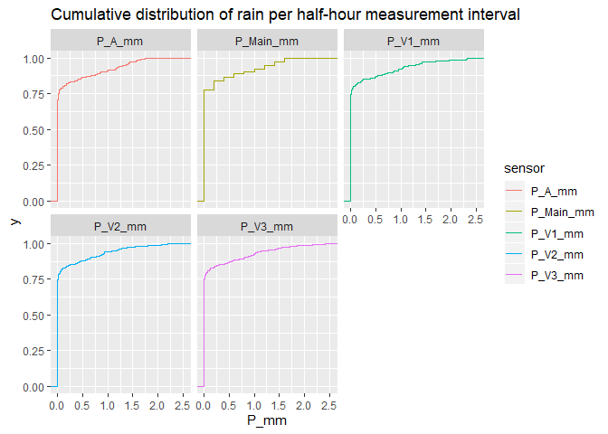

```r
ggplot(df, aes(P_mm, colour = sensor)) +
  stat_ecdf() +
  facet_wrap(~sensor) +
  labs(title="Cumulative distribution of rain per half-hour measurement interval")
```

```r
#what is difference in number of intervals with rain recorded?
df %>%
  mutate(s_type=sapply(1:nrow(df), function(x) {
    if(sensor[x]=="P_A_mm"){ "Atmos" } else {
      if(sensor[x]=="P_Main_mm"){ "Tip" } else { "Vaisala" } } } )) %>%
  group_by(sensor) %>%
  summarize(s_type=s_type[1],
            P_nonZero=length(which(P_mm>0)),
            P_zero=length(which(P_mm==0))) %>%
  ungroup() %>%
  group_by(s_type) %>%
  summarize(P_nonZero=mean(P_nonZero), P_zero=mean(P_zero), n=n()) %>%
  arrange(desc(P_nonZero)) %>%
  knitr::kable()
```

| s_type | P_nonZero | P_zero | n |
| --- | --- | --- | --- |
| Atmos | 98 | 235 | 1 |
| Vaisala | 84 | 249 | 3 |
| Tip | 74 | 259 | 1 |

- The table above shows tipping bucket had the least half-hour measurement intervals in which some precipitation is recorded with each gauge. The Main gauge (‘Tip’) recorded only 74 half-hours with rain, versus 98 by the Atmos gauge, and an average of 84 for the three Vaisala piezometric sensors.
  - This doesn’t necessarily mean that the Main gauge is undermeasuring precipitation - it could just be that precipitation takes more than one measurement period to build up enough to cause a tip.
- The graph below shows that for total cumulative precipitation, there is one outlier among the 5 sensors, Vaisala-2 (V2). The other four sensors are relatively close together, although the Atmos sensor is a bit higher:

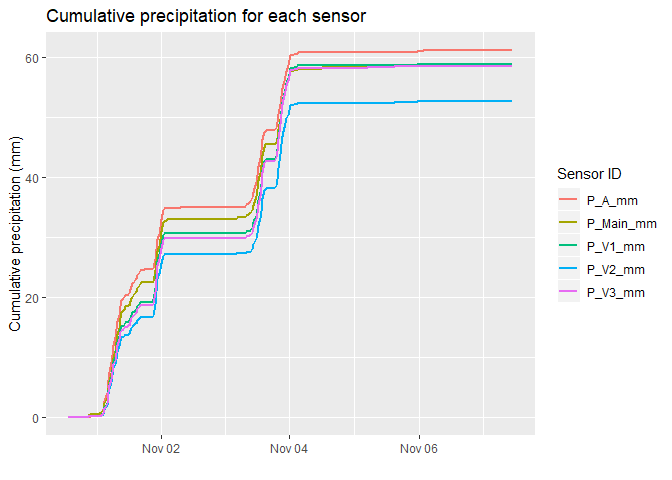

```r
df %>%
  group_by(sensor) %>%
  mutate(P_cumul = cumsum(P_mm)) %>%
  ggplot(aes(x=timestamp, y=P_cumul, colour = sensor)) +
    geom_line(size=1) +
    labs(y="Cumulative precipitation (mm)",
         title="Cumulative precipitation for each sensor",
         colour="Sensor ID",
         x="")
```

- Below is the cumulative precipitation from all 5 sensors, along with the mean cumulative P from all sensors.
  - Since the Vaisala-2 sensor seems to be an outlier that undermeasures precipitation, it seems that it is better to calculate our best estimate of the mean P based only on the other 4 sensors (P_tot.mean_nonV2).

```r
df.cumul <- df %>%
              group_by(sensor) %>%
              mutate(P_cumul = cumsum(P_mm)) %>%
              summarize(P_tot= round(max(P_cumul),1)) %>%
              ungroup() %>%
              mutate(is_V2 = sensor=="P_V2_mm",
                     P_tot_nonV2 = ifelse(is_V2,NA,P_tot),
                     P_tot.mean_all=mean(P_tot) %>% round(digits=1),
                     P_tot.mean_nonV2 = mean(P_tot_nonV2, na.rm=T)) %>%
              select(-P_tot_nonV2, -is_V2) %>%
              arrange(P_tot)

knitr::kable(df.cumul)
```

| sensor | P_tot | P_tot.mean_all | P_tot.mean_nonV2 |
| --- | --- | --- | --- |
| P_V2_mm | 52.6 | 57.9 | 59.2 |
| P_V3_mm | 58.4 | 57.9 | 59.2 |
| P_Main_mm | 58.6 | 57.9 | 59.2 |
| P_V1_mm | 58.8 | 57.9 | 59.2 |
| P_A_mm | 61.0 | 57.9 | 59.2 |

#### 2.1 Would you consider these differences meaningful or substantial between sensor type? What about between different individual sensors of the same sensor type (e.g., the 4 Vaisala WXT520 sensors)?

- Over the course of the week covered by the dataset, at least one of the sensors, Vaisala-2, shows a significant difference from the mean (table below). Vaisala-2 is 11.1% lower than the mean, while all others are 3% or less off from the mean. This is shown in the table below.
  - Here I’m using the mean of non-Vaisala-2 sensors in keeping with my answer above, but results would be similar if I used the mean of all five sensors.
- If this difference were to continue over the course of an average climate year in Vancouver (estimated at 1283 mm, as per class discussion), then it would mean that Vaisala-2 measured 143 mm less than the mean of the other sensors. Shown in the table below.
- How significant the differences are will depend on what the precipitation data is being used for - for general weather monitoring, this is not as concerning as if these instruments were to be used at different locations and their data compared to each other for more detailed research purposes. A calibration factor could also be applied to Vaisala-2’s results to bring it more in line with the other sensors, but you’d probably want more than a week of data to base that calibration on.
- As far as determining if any of the other sensors have meaningful differences, it is tough to say. The Atmos sensor measures 3% above the mean, but this mean P estimate is not necessarily the correct total precipitation - the Atmos sensor could be closest to the true measurement, we cannot know for sure from this dataset.
- I would feel OK about deploying all the sensors except Vaisala-2. I would be hesitant to deploy the Atmos sensor in an experiment where its data was being compared to one of the other sensors, especially in a wet location, just in case its error is truly 3% or more.

```r
vancouver_mean_P <- 1283
frac.of.annual.P <- df.cumul$P_tot.mean_nonV2[1] / vancouver_mean_P

df.diff <- df.cumul %>%
              select(-P_tot.mean_all) %>%
              mutate(P_diff.from.mean = P_tot-P_tot.mean_nonV2,
                     P_diff.pc = (P_diff.from.mean/P_tot.mean_nonV2) %>% round(digits=3),
                     P_diff_Vancouver.year = (P_diff.from.mean * 1/frac.of.annual.P) %>% round(digits=1) ) %>%
              arrange(P_tot)

knitr::kable(df.diff)
```

| sensor | P_tot | P_tot.mean_nonV2 | P_diff.from.mean | P_diff.pc | P_diff_Vancouver.year |
| --- | --- | --- | --- | --- | --- |
| P_V2_mm | 52.6 | 59.2 | -6.6 | -0.111 | -143.0 |
| P_V3_mm | 58.4 | 59.2 | -0.8 | -0.014 | -17.3 |
| P_Main_mm | 58.6 | 59.2 | -0.6 | -0.010 | -13.0 |
| P_V1_mm | 58.8 | 59.2 | -0.4 | -0.007 | -8.7 |
| P_A_mm | 61.0 | 59.2 | 1.8 | 0.030 | 39.0 |

- Between the Vaisala sensors, there is a pattern of two of the sensors measuring nearly identically, with the V2 sensor being about 6 mm lower over the week. Since these are all the same sensor type, the difference doesn’t come from a difference in the mechanism of measurement, so instead either comes from sensor error or error introduced by its placement (e.g. wind interference). Since V1 and V3 give measurements closer to the mean of all sensors, it seems likely that V2 is the one at fault. The V2 sensor should probably be deployed with caution, to less sensitive applications, and/or tested further in the lab.

```r
df.diff %>%
    filter(sensor=="P_V1_mm" | sensor=="P_V2_mm" | sensor=="P_V3_mm") %>%
    group_by(sensor) %>%
    arrange(sensor) %>%
    knitr::kable()
```

| sensor | P_tot | P_tot.mean_nonV2 | P_diff.from.mean | P_diff.pc | P_diff_Vancouver.year |
| --- | --- | --- | --- | --- | --- |
| P_V1_mm | 58.8 | 59.2 | -0.4 | -0.007 | -8.7 |
| P_V2_mm | 52.6 | 59.2 | -6.6 | -0.111 | -143.0 |
| P_V3_mm | 58.4 | 59.2 | -0.8 | -0.014 | -17.3 |

- If you just look at sensor types by taking a mean of all the Vaisala results into one row, then it can look like the Vaisala sensors as a group are off from the mean by 4.4%, or 56.3 mm over a mean Vancouver climate year. As shown above, this apparent difference is just because of one low sensor (V2) and the other Vaisalas seem fine:

```r
df.type <- df.diff %>%
            mutate(s_type=sapply(1:nrow(df.diff), function(x) { if(sensor[x]=="P_A_mm"){ "Atmos" } else { if(sensor[x]=="P_Main_mm"){ "Tip" } else { "Vaisala" } } } )) %>%
            group_by(s_type) %>%
            summarize_if(is.numeric, mean) %>%
            mutate(P_diff_Vancouver.year = round(P_diff_Vancouver.year,1))

knitr::kable( df.type )
```

| s_type | P_tot | P_tot.mean_nonV2 | P_diff.from.mean | P_diff.pc | P_diff_Vancouver.year |
| --- | --- | --- | --- | --- | --- |
| Atmos | 61.0 | 59.2 | 1.8 | 0.030 | 39.0 |
| Tip | 58.6 | 59.2 | -0.6 | -0.010 | -13.0 |
| Vaisala | 56.6 | 59.2 | -2.6 | -0.044 | -56.3 |

### 3. Estimate canopy storage for the forest block at UBC Farm (showing calculations and assumptions).

The equation to calculate canopy storage is: $S_{c}$= $c *$ $f_{t}$ $* LAI$

- **Canopy storage** equals the product of *fractional cover*, *film thickness*, and *LAI*.
  - film thickness is measured as a length, the other two quantities are dimensionless, so canopy storage is a length (i.e. a depth)
- **fractional cover:** I estimate this at **80%**.
  - *Assumptions:* This is an ocular estimate based on personal experience doing vegetation surveys. My margin of error on this is **+/- 10%**.
- **film thickness:** [Bouten et al. (1996)](https://pure.uva.nl/ws/files/1213998/1694_18947y.pdf) made measurements in a Douglas-fir plantation and determined that film thicknesses were 0.040, 0.045, 0.120, and 0.300 mm in the four layers of canopy cover that they identified. The mean of these four estimates is **0.126 mm**. This fits well with data in the table provided in class, which had values between 0.0762 and 0.1778 for trees and shrubs.
  - *Assumptions:* I am assuming a simplification by using only data from a Douglas-fir stand, when the cover at the UBC Farm was probably about half from species other than Douglas-fir. I am also assuming that the mean of Bouten et al.’s 4-layer estimate is applicable to the Douglas-fir at UBC Farm. Based on the range of their 4 estimates and the values presented in class, I estimate my margin of error on this estimate is **+/- 0.08**.
- **LAI**: I estimate this to be **5.75**. This is based on the data showed in class for HDF88 which was estimated at 6.6 and 7.2. I’ve been to HDF88 many times and I think it is a more densely spaced canopy with higher LAI than the forest block at UBC Farm. Also, this is informed by my personal experience having measured LAI at dozens of sites over the years. I think that the LAI of the UBC Farm stand is between 5 and 6.5, so I am using 5.75
  - *Assumptions*: I am assuming that the HDF88 measurements are accurate, that my memory of HDF88 is not flawed, and that I can reliably relate my past experience measuring LAI to the UBC Farm stand. My margin of error on this estimate is **+/- 0.75**.

Using my margin of error estimates, I can look at the range of possible canopy storage estimates:

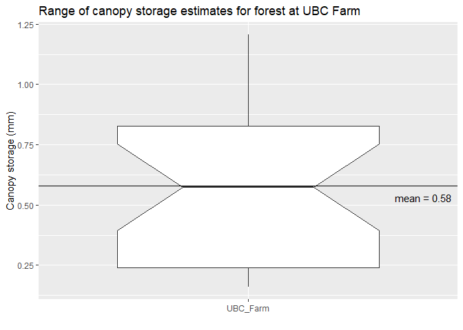

```r
#get range of canopy storage estimates
Sc.df <- tidyr::expand_grid(c=c(0.8,0.7,0.9),
                   f_t=c(0.126,0.046,0.206),
                   LAI=c(5.75, 5, 6.5))
Sc.df$Sc <- Sc.df$c * Sc.df$f_t * Sc.df$LAI

#what is the mean Sc?
mean.Sc <- round(mean(Sc.df$Sc),2)

#graph the Sc estimates
Sc.df$area <- factor("UBC_Farm")
ggplot(Sc.df, aes(x=area, y=Sc)) +
  geom_boxplot(notch=TRUE) +
  labs(x="",y="Canopy storage (mm)",title="Range of canopy storage estimates for forest at UBC Farm") +
  geom_abline(slope=0,intercept = mean.Sc) +
  annotate("text", x=1.5, y=mean.Sc-0.05, label= paste("mean =",mean.Sc))
```

### 4. Determine the total amount of precipitation for each sensor.

The total amount of precipitation for each sensor is:

```r
df %>%
  group_by(sensor) %>%
  summarize(P_total_mm = max(cumsum(P_mm))) %>%
  knitr::kable()
```

| sensor | P_total_mm |
| --- | --- |
| P_A_mm | 61.013 |
| P_Main_mm | 58.600 |
| P_V1_mm | 58.750 |
| P_V2_mm | 52.560 |
| P_V3_mm | 58.440 |

### 5. Starting with the code in the Rain Events code chunk above to determine:

#### Part A: Using the minimum measurable rainfall for each sensor type, determine the number and magnitude of events for each of the sensors.

The Atmos sensor measured 4 rain events, while all other sensors measured 5 rain events. This is the full summary of measurable open-field rain events for all sensors:

```r
#compile dataframe of rain events for each sensor
sensor_settings <- data.frame(sens=c("P_V1_mm","P_V2_mm","P_V3_mm","P_A_mm","P_Main_mm"),
                              thresh=c(0.01,0.01,0.01,0.017,0.2),
                              stringsAsFactors = F)

#loop through all sensors and summarize rain events
re.sens <- lapply(1:5, function(x){
  re <- RMevents(df.P,
                 ieHr = 6,
                 rainthresh = sensor_settings$thresh[x],
                 rain = sensor_settings$sens[x],
                 time = "timestamp")[["storms2"]]
  re$sensor <- sensor_settings$sens[x]
  re
})
re.s <- do.call(rbind.data.frame, re.sens)  %>%
          select( sensor, everything() )

#display data
DT::datatable( re.s )
```

|  | sensor | stormnum | StartDate | EndDate | rain |
| --- | --- | --- | --- | --- | --- |
| 1 | P_V1_mm | 1 | 2018-11-01T03:00:00Z | 2018-11-02T08:00:00Z | 30.53 |
| 2 | P_V1_mm | 2 | 2018-11-03T09:30:00Z | 2018-11-04T10:00:00Z | 27.99 |
| 3 | P_V1_mm | 3 | 2018-11-05T11:30:00Z | 2018-11-05T12:30:00Z | 0.02 |
| 4 | P_V1_mm | 4 | 2018-11-05T22:00:00Z | 2018-11-05T22:30:00Z | 0.12 |
| 5 | P_V1_mm | 5 | 2018-11-06T06:30:00Z | 2018-11-06T08:30:00Z | 0.09 |
| 6 | P_V2_mm | 1 | 2018-11-01T03:00:00Z | 2018-11-02T08:00:00Z | 27.12 |
| 7 | P_V2_mm | 2 | 2018-11-03T10:00:00Z | 2018-11-04T10:00:00Z | 25.2 |
| 8 | P_V2_mm | 3 | 2018-11-05T12:00:00Z | 2018-11-05T12:30:00Z | 0.01 |
| 9 | P_V2_mm | 4 | 2018-11-05T22:00:00Z | 2018-11-05T22:30:00Z | 0.13 |
| 10 | P_V2_mm | 5 | 2018-11-06T06:30:00Z | 2018-11-06T08:30:00Z | 0.1 |

[output cut: 14 more lines]

This is a condensed summary of measurable open-field rain events, taken from the table above:

```r
#summarize the rain events
re.s %>%
  group_by(sensor) %>%
  summarize(n_events=max(stormnum),
            total_mm=sum(rain),
            min_event_mm=min(rain),
            max_event_mm=max(rain),
            mean_event_mm=mean(rain) %>% round(digits=2)
            ) %>%
  arrange(desc(total_mm)) %>%
  select( sensor, everything() ) %>%
  knitr::kable()
```

| sensor | n_events | total_mm | min_event_mm | max_event_mm | mean_event_mm |
| --- | --- | --- | --- | --- | --- |
| P_A_mm | 4 | 61.013 | 0.068 | 34.867 | 15.25 |
| P_V1_mm | 5 | 58.750 | 0.020 | 30.530 | 11.75 |
| P_Main_mm | 5 | 58.600 | 0.200 | 33.000 | 11.72 |
| P_V3_mm | 5 | 58.440 | 0.020 | 29.720 | 11.69 |
| P_V2_mm | 5 | 52.560 | 0.010 | 27.120 | 10.51 |

#### Part B: Assess how many events would have “counted” if the gauges were in the forest measuring throughfall as P - Sc? (Use your calculation from question 2 as the value for Sc)

```r
#rain events after subtracting throughfall
re.tf <- re.s %>%
          mutate(rain=rain-mean.Sc) %>%
          filter( rain>0 ) %>%
          select( sensor, everything() )

DT::datatable( re.tf )
```

|  | sensor | stormnum | StartDate | EndDate | rain |
| --- | --- | --- | --- | --- | --- |
| 1 | P_V1_mm | 1 | 2018-11-01T03:00:00Z | 2018-11-02T08:00:00Z | 29.95 |
| 2 | P_V1_mm | 2 | 2018-11-03T09:30:00Z | 2018-11-04T10:00:00Z | 27.41 |
| 3 | P_V2_mm | 1 | 2018-11-01T03:00:00Z | 2018-11-02T08:00:00Z | 26.54 |
| 4 | P_V2_mm | 2 | 2018-11-03T10:00:00Z | 2018-11-04T10:00:00Z | 24.62 |
| 5 | P_V3_mm | 1 | 2018-11-01T03:00:00Z | 2018-11-02T08:00:00Z | 29.14 |
| 6 | P_V3_mm | 2 | 2018-11-03T10:00:00Z | 2018-11-04T10:00:00Z | 27.86 |
| 7 | P_A_mm | 1 | 2018-11-01T03:00:00Z | 2018-11-02T16:30:00Z | 34.287 |
| 8 | P_A_mm | 2 | 2018-11-03T10:30:00Z | 2018-11-04T15:00:00Z | 25.294 |
| 9 | P_Main_mm | 1 | 2018-11-01T03:00:00Z | 2018-11-02T09:00:00Z | 32.42 |
| 10 | P_Main_mm | 2 | 2018-11-03T11:00:00Z | 2018-11-04T10:00:00Z | 24.42 |

This is a condensed summary of measurable throughfall rain events, taken from the table above:

```r
#summarize the throughfall rain events
re.tf %>%
  group_by(sensor) %>%
  summarize(n_events=max(stormnum),
            total_mm=sum(rain),
            min_event_mm=min(rain),
            max_event_mm=max(rain),
            mean_event_mm=mean(rain) %>% round(digits=2)
            ) %>%
  arrange(desc(total_mm)) %>%
  knitr::kable()
```

| sensor | n_events | total_mm | min_event_mm | max_event_mm | mean_event_mm |
| --- | --- | --- | --- | --- | --- |
| P_A_mm | 2 | 59.581 | 25.294 | 34.287 | 29.79 |
| P_V1_mm | 2 | 57.360 | 27.410 | 29.950 | 28.68 |
| P_V3_mm | 2 | 57.000 | 27.860 | 29.140 | 28.50 |
| P_Main_mm | 2 | 56.840 | 24.420 | 32.420 | 28.42 |
| P_V2_mm | 2 | 51.160 | 24.620 | 26.540 | 25.58 |

### 6. Play around with the parameters ieHr and rainthresh and describe the influence on the number of rainfall events that would be counted as open field precipitation, and how many would now be counted as throughfall.

*Assumptions*: In addition to the assumptions outlined above in determining my canopy storage estimate, the primary assumption here is that the sensors would be able to measure throughfall equal to open-field precipitation minus canopy storage. In reality, a component of the precipitation making it through the canopy layer to the forest floor would come as stemflow. Additionally, the precipitation moving through as throughfall would likely be uneven, due to convergence of foliage and large drops, so it would be better to extend the sensors’ fields of measurement using troughs or other similar mechanisms so they could integrate larger area of measurements into their readings.

```r
#loop to run through different ieHr and rainthresh settings and summarize event counts

#settings to test
ieHr <- c(2,4,6,12,24)
rainthresh <- c(0.1,0.5,1,5,50)

#establish lists to store outputs in
outlist.op <- outlist.tf <- outlist.df.op <- outlist.df.tf <-NULL

#loop through settings and summarize rain events
for(ii in 1:length(ieHr)){
  iehr <- ieHr[ii] #establish this iteration setting of ieHr

  for(rr in 1:length(rainthresh)){
    rt <- rainthresh[rr] #establish this iteration setting of rainthresh

    #compile dataframe of rain events for each sensor, 2:6 is index of data columns in df.P
    re.sens <- lapply(2:6, function(x){
      re <- RMevents(df.P,
                     ieHr = iehr,
                     rainthresh = rt,
                     rain = names(df.P)[x], time = "timestamp")[["storms2"]]

      #fill with NAs if zero events found
      if(nrow(re)==0){ re <- data.frame(stormnum=0,
                                        StartDate=as.POSIXct(NA),
                                        EndDate=as.POSIXct(NA),
                                        rain=as.numeric(NA)) }
      re$sensor <- names(df.P)[x] #add column of sensor name

      re #lapply output
    })
    #bind loop outputs into a dataframe
    re.op <- do.call(rbind.data.frame, re.sens)

      #modify for throughfall
      re.tf <- re.op %>%
            mutate(rain=rain-mean.Sc) %>%
            filter( rain>0 | is.na(rain)  )

    #summarize the rain events
      #open-field
      re.op.n <- re.op %>%
                group_by(sensor) %>%
                summarize(n_events=max(stormnum))
      re.op.n$ieHr <- iehr
      re.op.n$rainthresh <- rt
      outlist.op[[rr]] <- re.op.n

      #throughfall
      re.tf.n <- re.tf %>%
                group_by(sensor) %>%
                summarize(n_events=max(stormnum))
      re.tf.n$ieHr <- iehr
      re.tf.n$rainthresh <- rt
      outlist.tf[[rr]] <- re.tf.n

  }#end rr

  #bind loop outputs into dataframes
  df.op <- do.call(rbind.data.frame, outlist.op)
  df.tf <- do.call(rbind.data.frame, outlist.tf)

  #store dfs in a list
  outlist.df.op[[ii]] <- df.op
  outlist.df.tf[[ii]] <- df.tf

}#end ii

#compile list from loops into dataframe
df2.op <- do.call(rbind.data.frame,outlist.df.op)
df2.tf <- do.call(rbind.data.frame,outlist.df.tf)

#summarize median and n_zero event counts
op.re <- df2.op %>%
            group_by(ieHr,rainthresh) %>%
            summarize(median_event_count=median(n_events),
                      zero_event_count=length(which(n_events==0)))
tf.re <- df2.tf %>%
            group_by(ieHr,rainthresh) %>%
            summarize(median_event_count=median(n_events),
                      zero_event_count=length(which(n_events==0)))

#set  up classes for graphing
  #for establishing factor range
  max.events <- max( max(op.re$median_event_count),
                     max(tf.re$median_event_count) )
#open field factor setup
op.re$ieHr.fac <- as.factor(op.re$ieHr)
op.re$rt.fac <- as.factor(op.re$rainthresh)
op.re$zero_fac <- factor(op.re$zero_event_count, levels=c(0:5))
op.re$med_fac <- factor(op.re$median_event_count,  levels=c(0:max.events))
#throughfall factor setup
tf.re$ieHr.fac <- as.factor(tf.re$ieHr)
tf.re$rt.fac <- as.factor(tf.re$rainthresh)
tf.re$zero_fac <- factor(tf.re$zero_event_count, levels=c(0:5))
tf.re$med_fac <- factor(tf.re$median_event_count,  levels=c(0:max.events))
```

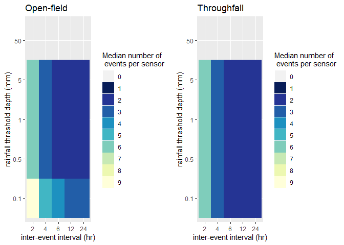

```r
#OPEN FIELD GRAPHS
#create graph for median number of open-field events per sensor:
op.med <- op.re %>%
  ggplot(aes(x=ieHr.fac, y=rt.fac, fill=med_fac)) +
  geom_tile() +
  scale_fill_brewer(palette="YlGnBu", drop=FALSE, direction = -1) +
  labs(x="inter-event interval (hr)",
       y="rainfall threshold depth (mm)",
       fill="Median number of \n events per sensor",
       title="Open-field")

#create graph for number sensors measuring zero open-field events at each setting:
op.zero <- op.re %>%
  ggplot(aes(x=ieHr.fac, y=rt.fac, fill=zero_fac)) +
  geom_tile() +
  scale_fill_brewer(palette="YlOrRd", drop=FALSE) +
  labs(x="inter-event interval (hr)",
       y="rainfall threshold depth (mm)",
       fill="Number of sensors \n showing zero events \n at this setting",
       title="Open-field")

#THROUGHFALL GRAPHS
#create graph for median number of throughfall events per sensor:
tf.med <- tf.re %>%
  ggplot(aes(x=ieHr.fac, y=rt.fac, fill=med_fac)) +
  geom_tile() +
  scale_fill_brewer(palette="YlGnBu", drop=FALSE, direction=-1) +
  labs(x="inter-event interval (hr)",
       y="rainfall threshold depth (mm)",
       fill="Median number of \n events per sensor",
       title="Throughfall")

#create graph for number sensors measuring zero throughfall events at each setting:
tf.zero <- tf.re %>%
  ggplot(aes(x=ieHr.fac, y=rt.fac, fill=zero_fac)) +
  geom_tile() +
  scale_fill_brewer(palette="YlOrRd", drop=FALSE) +
  labs(x="inter-event interval (hr)",
       y="rainfall threshold depth (mm)",
       fill="Number of sensors \n showing zero events \n at this setting",
       title="Throughfall")

#display graphs side-by-side
gridExtra::grid.arrange(op.med, tf.med, ncol=2)
```

- **The effect of varying the inter-event interval:**
  - As the interval length is decreased, there are more distinct events counted because what was considered to be a break in precipitation during a longer event when interval is set higher, is now considered to be a break between separate events with shorter intervals.
  - If the inter-event interval is set to 2 hours with a threshold depth of 0.1 mm, the median number of events counted by the sensors can be up to 9 in an open-field setting.
  - There is no difference between setting the interval at 12 or 24 hours at the threshold depths tested.
  - At most threshold depths, except 0.1 mm in the open-field scenario, there is no difference between the number of events at 6-, 12-, or 24-hour inter-event intervals.
- **The effect of varying the rainfall threshold depth:**
  - For each interval setting, in both open-field and throughfall scenarios, there is no difference in the median number of rain events counted by setting the threshold depth between 0.5 and 5 mm. This indicates that events tended to be larger than 5 mm and would trigger an event being counted at any of these settings.
  - At the settings tested, the threshold depth does not have an effect on the number of throughfall events counted, except when the threshold is set to an extreme value of 50 mm.

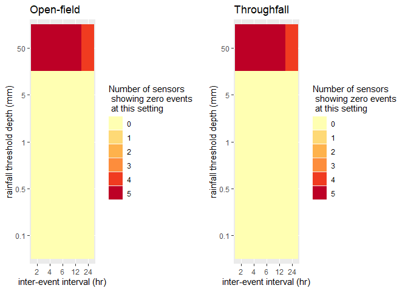

```r
gridExtra::grid.arrange(op.zero, tf.zero, ncol=2)
```

The graphs above show that you need to use extreme settings to have any of the sensors fail to count rain events at all. If the threshold depth is set unreasonably high at 50 mm, then some sensors count zero rainfall events. Otherwise, no sensors miss rainfall events completely.

The table below summarizes the data shown in the graphs above, giving the median number of rain events counted with each setting (median_OPEN, median_THROUGH), and the number of sensors counting zero events at each setting (zeroCount_OPEN, zeroCOUNT_MEDIAN):

```r
#prepare data for merging
  op.re$type <- "open"
  tf.re$type <- "throughfall"

  op.re$median_OPEN <- op.re$median_event_count
  tf.re$median_THROUGH <- tf.re$median_event_count
  op.re$zeroCount_OPEN <- op.re$zero_event_count
  tf.re$zeroCount_THROUGH <- tf.re$zero_event_count

#merge data
all.re <- merge(op.re, tf.re, by=c("ieHr","rainthresh"), all=T)

#display selected columns
all.re %>%
  select(ieHr, rainthresh,
         median_OPEN, median_THROUGH,
         zeroCount_OPEN, zeroCount_THROUGH) %>%
  arrange(desc(ieHr), desc(rainthresh)) %>%
  DT::datatable()
```

|  | ieHr | rainthresh | median_OPEN | median_THROUGH | zeroCount_OPEN | zeroCount_THROUGH |
| --- | --- | --- | --- | --- | --- | --- |
| 1 | 24 | 50 | 0 | 0 | 4 | 4 |
| 2 | 24 | 5 | 2 | 2 | 0 | 0 |
| 3 | 24 | 1 | 2 | 2 | 0 | 0 |
| 4 | 24 | 0.5 | 2 | 2 | 0 | 0 |
| 5 | 24 | 0.1 | 3 | 2 | 0 | 0 |
| 6 | 12 | 50 | 0 | 0 | 5 | 5 |
| 7 | 12 | 5 | 2 | 2 | 0 | 0 |
| 8 | 12 | 1 | 2 | 2 | 0 | 0 |
| 9 | 12 | 0.5 | 2 | 2 | 0 | 0 |
| 10 | 12 | 0.1 | 3 | 2 | 0 | 0 |

[output cut: 15 more lines]